# TP4

Elliott Perryman, Jan Zavadil, Ignat Sabaev

4/4/2022

## 1. Import and first explorations

Firstly, we load the data from the text file and create an R graph structure.

```r
library ( igraph )
dat <- read.table ("lesmis.txt", header = FALSE , sep = "\t")
misgraph <- simplify ( graph.data.frame ( dat , directed = FALSE ))
```

#### a)

This graph structure is plotted using $\texttt{plot.igraph}$ function. It supports a vast variety of ways to fine tune the looks of the graph. It is possible to specify the layout of the graph using the $\texttt{layout}$ parameter by either providing the coordinates for each vertex or by using one of the predefined layouts, eg. circle, sphere or fruchterman.reingold as seen in the following plots.

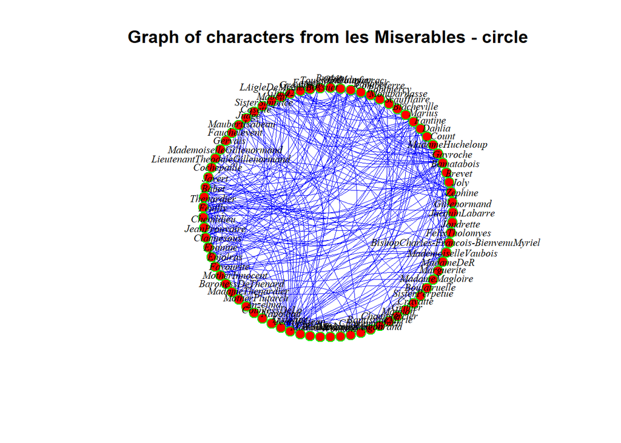

```r
plot.igraph(misgraph, layout = layout.circle, vertex.color = "red", edge.color = "blue", vertex.size = 8, vertex.frame.color = "green", vertex.label.font = 3, vertex.label.cex = 0.7, vertex.label.dist = 1.5, vertex.label.color = "black", edge.curved = TRUE,edge.width = 0.2,  main = "Graph of characters from les Miserables - circle")
```

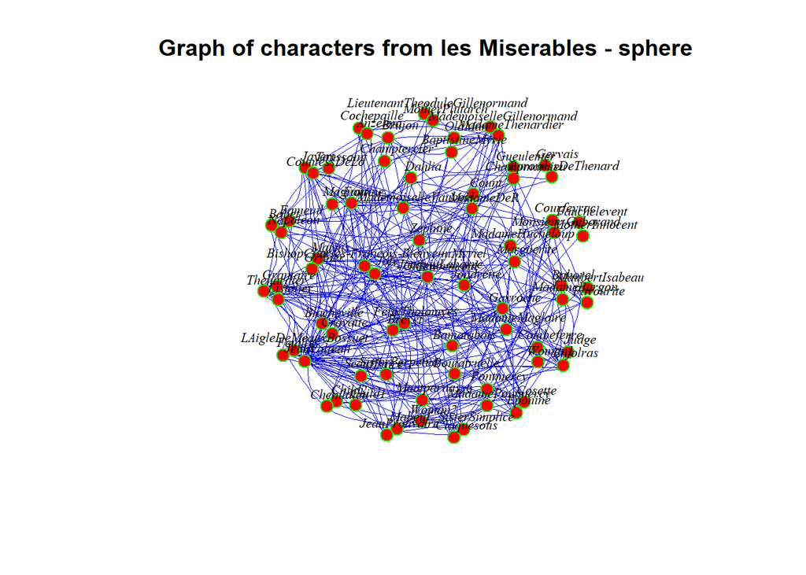

```r
plot.igraph(misgraph, layout = layout.sphere, vertex.color = "red", edge.color = "blue", vertex.size = 8, vertex.frame.color = "green", vertex.label.font = 3, vertex.label.cex = 0.7, vertex.label.dist = 1.5, vertex.label.color = "black", edge.curved = TRUE,edge.width = 0.2,  main = "Graph of characters from les Miserables - sphere")
```

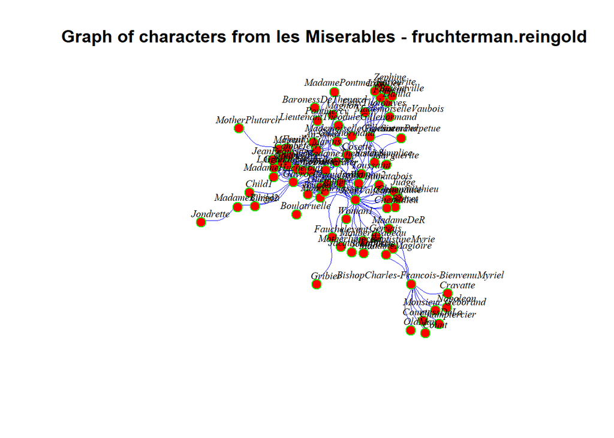

```r
plot.igraph(misgraph, layout = layout.fruchterman.reingold, vertex.color = "red", edge.color = "blue", vertex.size = 8, vertex.frame.color = "green", vertex.label.font = 3, vertex.label.cex = 0.7, vertex.label.dist = 1.5, vertex.label.color = "black", edge.curved = TRUE, edge.width = 0.2, main = "Graph of characters from les Miserables - fruchterman.reingold")
```

#### b)

```r
size = gsize(misgraph)
order = gorder(misgraph)
dens = edge_density(misgraph)
diam = diameter(misgraph, weights = NULL)
```

The graph in question is undirected, its size is 254, order 77, density 0.0868079 and diameter 5.

#### c)

```r
set.seed (3)
V(misgraph)$label.cex <- (degree(misgraph)+10) / max(degree(misgraph))
l <- layout_with_fr(misgraph)
```

This code sets the size of the label of a vertex depending on its degree. Its affect on the plot can be seen in the following plot.

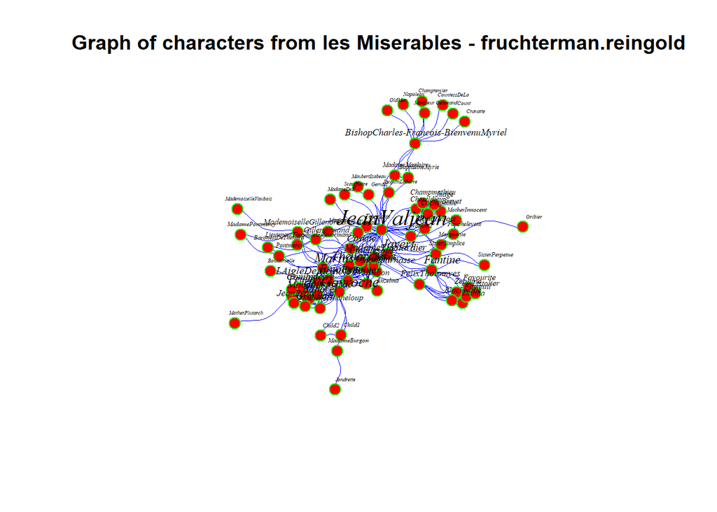

```r
plot.igraph(misgraph, layout = layout.fruchterman.reingold, vertex.color = "red", edge.color = "blue", vertex.size = 8, vertex.frame.color = "green", vertex.label.font = 3, vertex.label.dist = 1.5, vertex.label.color = "black", edge.curved = TRUE, edge.width = 0.2, main = "Graph of characters from les Miserables - fruchterman.reingold")
```

## 2 Community detection

### 2.1 Hierarchical agglomerative clustering

#### a)

In the beginning, all the vertices are considered to belong by themselves to their own cluster, at each step of the clustering the two “closest” clusters with regard to a certain metric are joined. The vertex-vertex, cluster-vertex and cluster-cluster metric must be defined.

#### b)

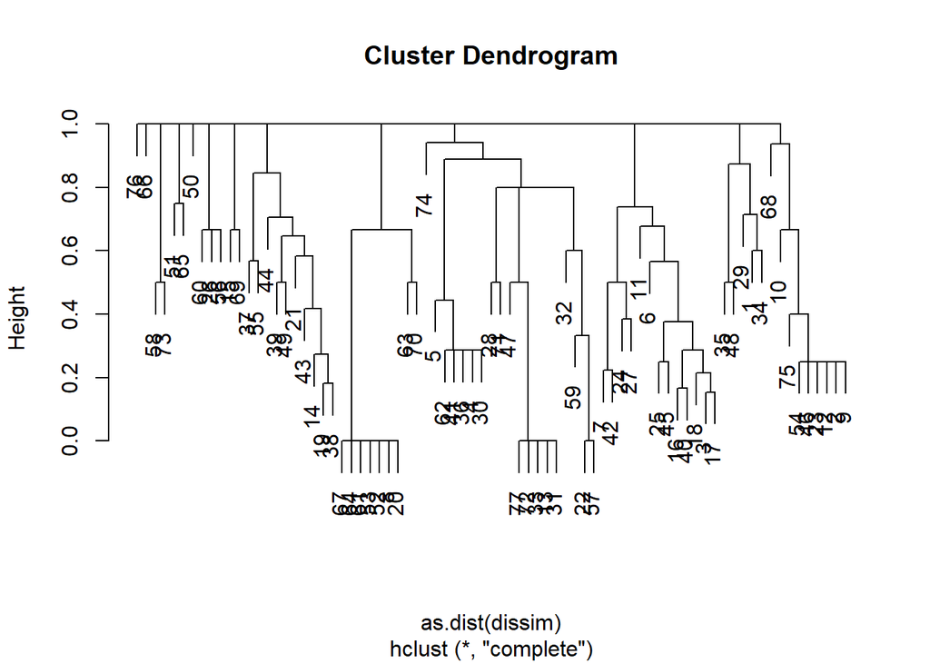

```r
dissim = 1 - similarity(misgraph)
mishclust = hclust(as.dist(dissim))
plot(mishclust)
```

#### c)

The following code cuts the cluster dendrogram from previous part so that the graph is divided into $i$ communities, where $i$ goes from 1 to 10.

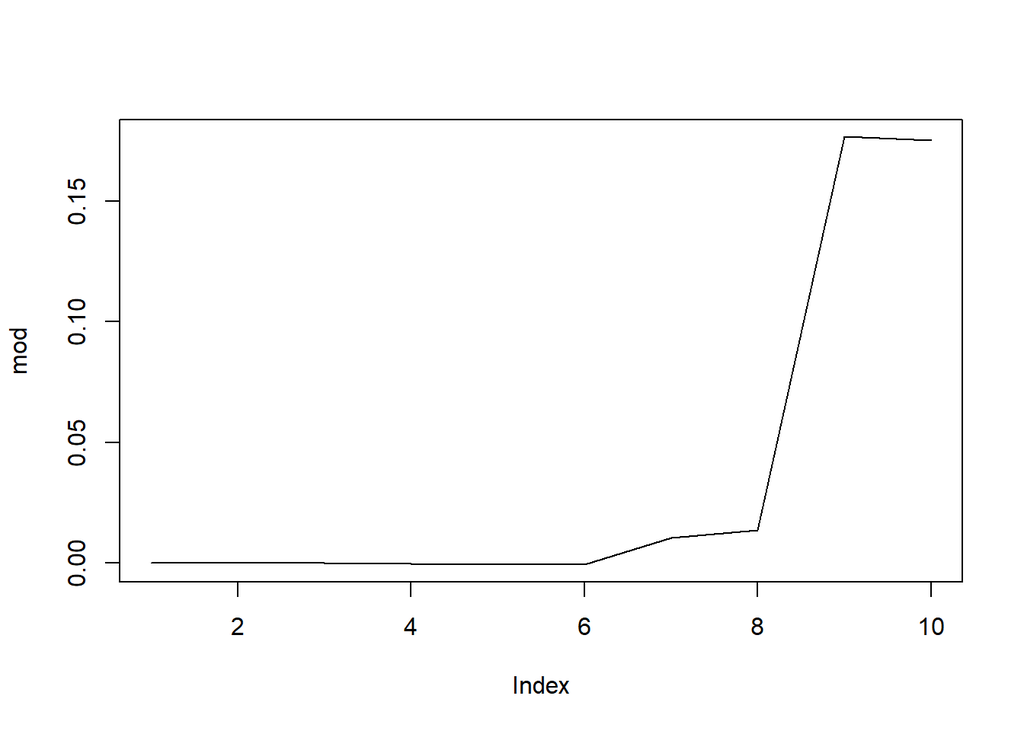

```r
mod = c()
for (i in 1:10){
  labels = cutree(mishclust, i)
  mod[i] = modularity(x = misgraph , membership = labels)
}
plot ( mod , type ="l")
```